# GEO 330 / SUD 430

Sustainable Urban Transportation

C. Scott Smith, PhD AICP  
Epidemiologist, Cook County Department of Public Health  
Urban Programs Advisor, Chaddick Institute  
c.scott.smith@depaul.edu

2026-09-15

## Introductions

- Name
- Degree program
- Preferred mode of travel

## What Is Sustainability?

- Individually consider your own understanding of sustainability
- Use the link below to submit three (or more) sustainability concepts
- Break out into groups of 3
- Spend 5 minutes sharing your ideas of sustainability
- Add any additional concepts/words using the same link

**Poll:** `PollEv.com/urbantransport`

## What Is Sustainability?

**Poll:** `PollEv.com/urbantransport`

## What Is a Transportation System?

A system is an interconnected set of elements that is coherently organized in a way that achieves something. A system consists of three kinds of things: elements, interconnections, and a function or purpose. (Meadows, 2008)

In its simplest form, a transportation system consists of vehicles/modes, paths/networks and behaviors.

Like all systems, transportation systems are also situated in time (i.e., historical) and space/place and exhibit adaptive, dynamic, goal-seeking, self-preserving, and sometimes evolutionary behavior.

## In-Class Assignment #1

[video not shown]

- How many modes are represented in the video?
- How would you characterize this transportation system?
- Does this transportation system have elements of sustainability? Why and/or why not?
- What other information would you need to know to evaluate and improve the sustainability of this and other transportation systems?

## Streets as Public Space

## Early Urban Transit

## Cable Cars in Chicago

Cable cars were installed in Chicago to replace horsecars, which were vehicles pulled by horses along railways in the street.

Chicago had the largest cable car system in the country in terms of ridership and actual cars. (Chicago History Museum)

The technology enabled the expansion of the city and helped tie outlying areas to the downtown as well as laying the groundwork for later transit systems.

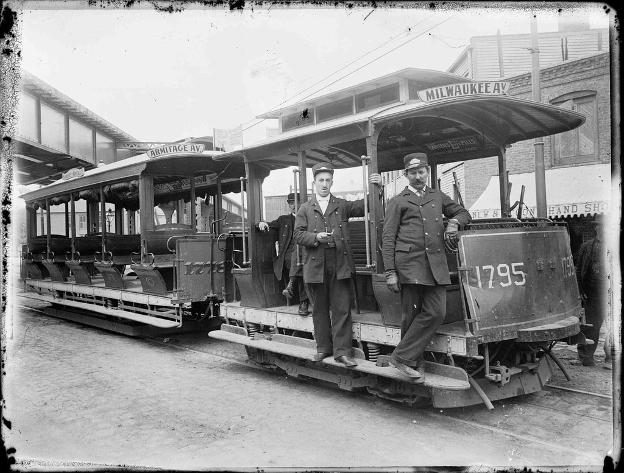

Cable car crew, Milwaukee Avenue line, Chicago

## The Automobile Era

The 1950s through 1990s is marked by geographic dispersion of housing and employment and the provision of automobile infrastructure to serve it.

> “If you plan for cars and traffic, you get cars and traffic. If you plan for people and places, you get people and places.” — Fred Kent, 2005

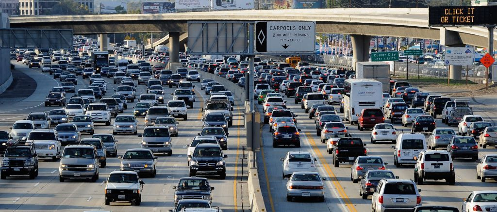

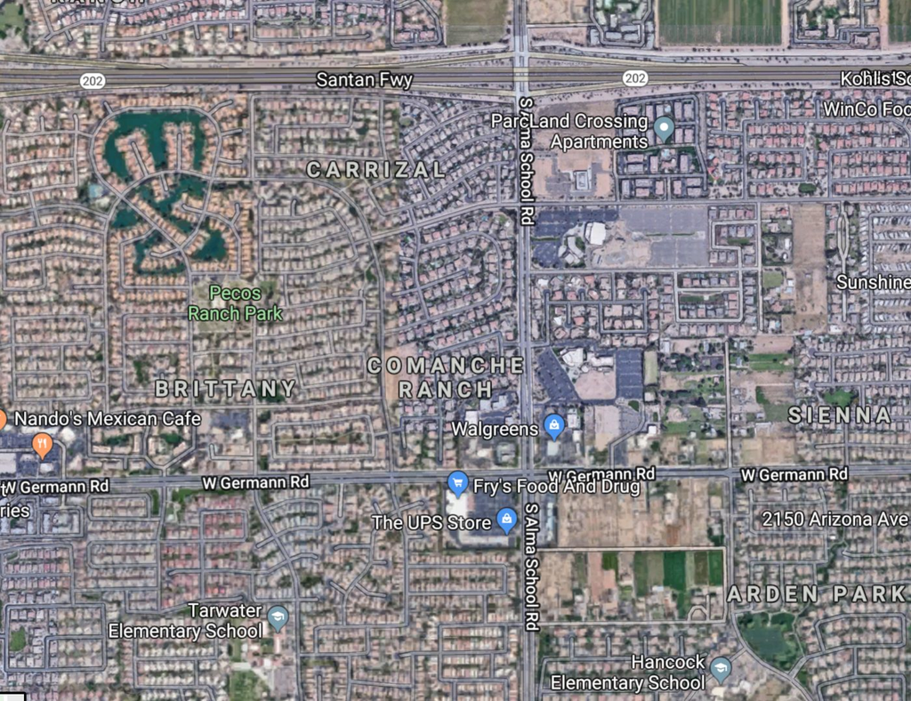

## Density and Transportation Emissions

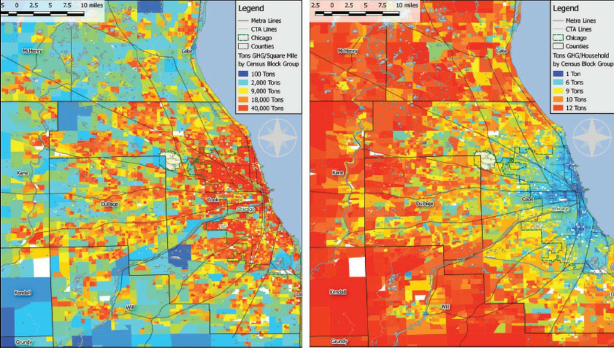

Transportation-related greenhouse gas emissions by census block group, Chicago region — per square mile (left) vs. per household (right)

## Theory of Routine Mode Choice

[figure not shown]

Schneider (2013), *Transport Policy*

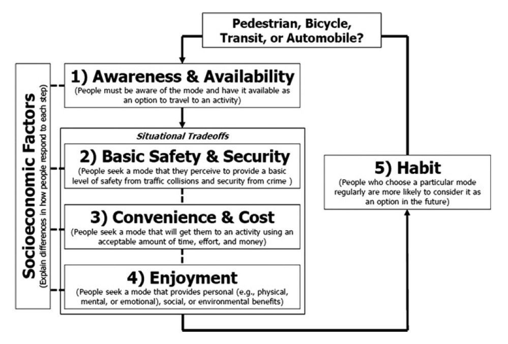

Five-step operational framework for routine mode choice decisions (Schneider, 2013)

## Designing for Sustainable Transportation

So how can we design communities that offer safer, more ecologically sound, more economically efficient and more socially equitable transportation opportunities?

## The Transportation Hierarchy

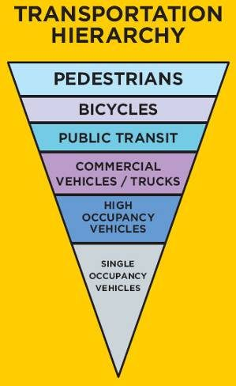

Transportation hierarchy: prioritizing modes by sustainability and vulnerability

## Applied Example: The Leading Pedestrian Interval

[figure not shown]

A Leading Pedestrian Interval (LPI) typically gives pedestrians a 3–7 second head start when entering an intersection with a corresponding green signal in the same direction of travel.

LPIs have been shown to reduce pedestrian-vehicle collisions as much as 60% at treated intersections.

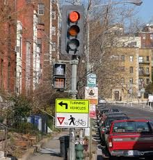

A bicycle signal head paired with a “turning vehicles yield” sign — another low-cost signal treatment